# 01_11B_MCU_Regional_Box_Office_Patterns

### MCU 영화 27편 - 지역별 박스오피스 패턴 분석

### 학습 내용

- 기본 분석([01_11_MCU_MOVIE_INFO](https://ldjwj.github.io/dataAnalysis/01_11_MCU_MOVIE_INFO.html), [01_11_MCU_MOVIE_INFO_02](https://ldjwj.github.io/dataAnalysis/01_11_MCU_MOVIE_INFO_02.html))에서 한 걸음 더 들어가기
- 데이터가 27행뿐일 때 **회귀 모델이 과적합되는 이유**를 확인하고, 대신 **비중(%) 비교 분석**으로 질문에 답하기
- 여러 파일을 합치고(`concat`, `melt`) **plotly 인터랙티브 차트**(누적 막대, 히트맵, 산점도)로 표현하기

### 내용

- 0. 기본 분석 돌아보기 - 무엇을 보완할까?
- 1. 데이터 준비 (5개 지역 파일 합치기, 데이터 품질 확인)
- 2. 지역별 흥행 비중 - 전체 / 페이즈별
- 3. 영화별 지역 비중 변화 (개봉 순서)
- 4. 국가별 상위 시장
- 5. 예산 대비 흥행 수익
- 6. 정리

### 0. 기본 분석 돌아보기 - 무엇을 보완할까?

- **선형회귀로 meta_user_score 예측** (입력 변수 6개, train 24편 / test **3편**)
  - 테스트 R² **-0.72**, MAE 0.48 → 평균값으로 예측하는 것보다도 못한 결과
  - 영화가 27편뿐인데 변수가 6개이고, 테스트 점수가 단 3편에 의해 결정된다. (아래에서 학습 점수와 비교해 과적합을 확인)
- **아시아 지역만 합계 비교** : 중국 3,030 > 한국 1,059 > 호주 683 (백만 달러) 순
  - 중국에 결측치가 있어 boxplot이 그려지지 않았고, 왜 비어 있는지는 확인하지 않았다.
  - 금액(절대값)만 비교하면 흥행이 큰 영화(어벤져스 시리즈)의 영향이 너무 커진다 → **비중(%)** 으로 보면 영화끼리 공정하게 비교할 수 있다.
- **나머지 4개 지역 파일(북미, 유럽, 중동아프리카, 남미)과 예산 정보는 활용하지 않았다.**

### 필수 라이브러리 불러오기

```python
import pandas as pd
import numpy as np
import seaborn as sns
import matplotlib.pyplot as plt
import plotly.express as px
import plotly.io as pio
import warnings
warnings.filterwarnings('ignore')

pio.renderers.default = 'notebook'   # HTML 파일에 plotly.js를 포함 (오프라인에서도 동작)

# 한글 폰트 설정
# - koreanize-matplotlib이 설치되어 있으면 OS와 상관없이 나눔고딕을 사용 (pip install koreanize-matplotlib)
# - 없으면 OS에 맞는 기본 한글 폰트를 사용
try:
    import koreanize_matplotlib
except ImportError:
    import platform
    plt.rcParams['font.family'] = {'Windows': 'Malgun Gothic',
                                   'Darwin': 'AppleGothic'}.get(platform.system(), 'NanumGothic')
plt.rcParams['axes.unicode_minus'] = False

sns.set_theme(style='whitegrid', font=plt.rcParams['font.family'])
```

#### 0-1. 기본 분석의 선형회귀 다시 보기 - 과적합 확인

- 기본 분석과 같은 변수·같은 분할(`random_state=0`)로 **학습 점수**와 **테스트 점수**를 함께 본다.
- 그리고 27편을 한 편씩 돌아가며 테스트로 쓰는 **LOOCV(Leave-One-Out 교차 검증)** 로 다시 평가한다.

```python
from sklearn.linear_model import LinearRegression
from sklearn.model_selection import train_test_split, LeaveOneOut, cross_val_predict
from sklearn.metrics import r2_score, mean_absolute_error

mov_info = pd.read_csv("./data/Marvel/movie_info.csv", encoding='utf-8-sig')  # 첫 컬럼명 앞의 BOM 제거
sel = ['production_budget_in_million_(USD)', 'worldwide_collection_in_million_(USD)',
       'tomatometer', 'tomato_audience_score', 'imdb', 'metascore']
X, y = mov_info[sel], mov_info['meta_user_score']

X_train, X_test, y_train, y_test = train_test_split(X, y, test_size=0.1, random_state=0)
model = LinearRegression().fit(X_train, y_train)
print(f'학습 R² : {model.score(X_train, y_train):.2f}  /  테스트 R² : {model.score(X_test, y_test):.2f}  (테스트 {len(y_test)}편)')

# LOOCV : 27번 학습, 매번 1편을 예측
pred = cross_val_predict(LinearRegression(), X, y, cv=LeaveOneOut())
print(f'LOOCV R² : {r2_score(y, pred):.2f},  MAE : {mean_absolute_error(y, pred):.2f}')
print(f'(비교) 평균값으로만 예측할 때 MAE : {(y - y.mean()).abs().mean():.2f}')
```

```
학습 R² : 0.86  /  테스트 R² : -0.72  (테스트 3편)
LOOCV R² : 0.30,  MAE : 0.57
(비교) 평균값으로만 예측할 때 MAE : 0.78
```

```python
# 가장 크게 틀린 영화
err = pd.DataFrame({'영화': mov_info['movie_title'], '실제': y, '예측(LOOCV)': pred.round(2)})
err['오차'] = (err['실제'] - err['예측(LOOCV)']).round(2)
err.reindex(err['오차'].abs().sort_values(ascending=False).index).head(4)
```

|  | 영화 | 실제 | 예측(LOOCV) | 오차 |
| --- | --- | --- | --- | --- |
| 20 | Captain Marvel | 3.0 | 6.54 | -3.54 |
| 25 | Eternals | 6.3 | 8.09 | -1.79 |
| 23 | Black Widow | 6.1 | 7.56 | -1.46 |
| 24 | Shang-Chi and the Legend of the Ten Rings | 7.1 | 8.39 | -1.29 |

- 한줄 확인 : 학습 R² **0.86** vs 테스트 R² **-0.72** → 학습 데이터에는 잘 맞지만 새 영화는 맞히지 못하는 전형적인 **과적합**
  - LOOCV로 27편 모두를 한 번씩 평가하면 R² **0.30**, MAE **0.57**(평균값 예측 0.78보다는 낫다). 테스트 3편짜리 점수는 믿기 어렵다는 뜻
  - 가장 크게 틀린 영화는 **Captain Marvel**(실제 3.0, 예측 6.54). 평론가·IMDb 점수는 평범한데 사용자 점수만 유독 낮은 **특이값** 한 편이 결과를 크게 흔든다.
- 27편으로는 신뢰할 만한 예측 모델을 만들기 어렵다. 이번에는 예측 대신 **"어느 지역·국가에서 얼마나 벌었나"를 비중으로 비교**한다.

### 1. 데이터 준비

#### 1-1. 5개 지역 파일을 하나의 긴(long) 표로 합치기

- 각 파일은 `영화 × 국가` 모양의 넓은(wide) 표 → `melt`로 (영화, 국가, 금액) 형태로 바꾸고 지역 이름을 붙여 `concat`

```python
mov_info['개봉일'] = pd.to_datetime(mov_info['release_date'], format='%B %d, %Y')
mov_info['개봉연도'] = mov_info['개봉일'].dt.year
mov_info = mov_info.rename(columns={'production_budget_in_million_(USD)': '예산',
                                    'worldwide_collection_in_million_(USD)': '전세계흥행'})
order = mov_info.sort_values('개봉일')['movie_title'].tolist()   # 개봉 순서

files = {'북미': 'north_america', '유럽': 'europe', '아시아태평양': 'asia_pacific',
         '중동아프리카': 'middle_east_and_africa', '남미': 'south_america'}
regions = list(files)

frames = []
for region, name in files.items():
    d = pd.read_csv(f"./data/Marvel/{name}_box_office.csv")
    d = d.melt(id_vars='movie_title', var_name='국가', value_name='흥행')
    d['지역'] = region
    frames.append(d)
bo = pd.concat(frames, ignore_index=True)
print(bo.shape)
bo.head()
```

```
(1971, 4)
```

|  | movie_title | 국가 | 흥행 | 지역 |
| --- | --- | --- | --- | --- |
| 0 | Iron Man | USA_and_Canada | 319.03 | 북미 |
| 1 | The Incredible Hulk | USA_and_Canada | 134.81 | 북미 |
| 2 | Iron Man 2 | USA_and_Canada | 312.43 | 북미 |
| 3 | Thor | USA_and_Canada | 181.03 | 북미 |
| 4 | Captain America: The First Avenger | USA_and_Canada | 176.65 | 북미 |

- 한줄 확인 : 27편 × 73개 컬럼(국가·기타 항목) = **1,971행**의 긴 표가 되었다. (단위: 백만 달러)

#### 1-2. 데이터 품질 확인

- ① 지역 합계 = 전세계 흥행인가? ② 결측치는 어디에? ③ 이상한 값은 없나?

```python
# ① 지역 합계와 전세계 흥행 비교
region_sum = bo.pivot_table(index='movie_title', columns='지역', values='흥행', aggfunc='sum')[regions]
check = region_sum.sum(axis=1) - mov_info.set_index('movie_title')['전세계흥행']
print(f'(지역 합계 - 전세계 흥행) 최대 차이 : {check.abs().max():.2f} 백만 달러')

# ② 결측치가 많은 국가
na = bo[bo['흥행'].isna()].groupby('국가').size().sort_values(ascending=False)
print('결측이 있는 국가 수 :', len(na))
print(na.head(5).to_string())
print('중국 결측 영화 :', bo.query("국가 == 'China' and 흥행.isna()")['movie_title'].tolist())
```

```
(지역 합계 - 전세계 흥행) 최대 차이 : 0.05 백만 달러
결측이 있는 국가 수 : 38
국가
Kuwait     22
Kenya      22
Ghana      20
Estonia    18
Latvia     18
중국 결측 영화 : ['Thor', 'Captain America: The First Avenger', 'Black Widow', 'Shang-Chi and the Legend of the Ten Rings', 'Eternals', 'Spider-Man: No Way Home']
```

- 한줄 확인 : 지역 합계와 전세계 흥행의 차이는 최대 **0.05(백만 달러)** 로 반올림 수준 → 5개 지역 파일이 전 세계를 빠짐없이 나눈 것이다.
  - 결측(NaN)은 대부분 작은 시장(케냐, 쿠웨이트, 가나 등)에서 집계가 없는 경우로, **0으로 보고 합계**를 내도 된다.
  - 단 **중국 결측 6편** 중 Black Widow, Shang-Chi, Eternals, Spider-Man: No Way Home(2021년, 페이즈 4) 4편은 **중국에서 개봉하지 않은 영화**이고, Thor, Captain America: The First Avenger(2011년)는 데이터에 값이 없다. 페이즈 4의 아시아 비중을 해석할 때 꼭 기억하자.

```python
# ③ 'Other_...' 와 중미/카리브 컬럼 값 비교
odd = ['Central America', 'Caribbean', 'Other_European_Countries', 'Other_Asia_Pacific_Countries',
       'Other_Middle_East_and_African_Countries', 'Other_South_American_Countries']
odd_tbl = bo[bo['국가'].isin(odd)].pivot_table(index='movie_title', columns='국가', values='흥행').loc[order]
print('6개 컬럼 값이 모든 영화에서 같은가? :', (odd_tbl.nunique(axis=1) == 1).all())
print(f"전체 흥행에서 6개 컬럼이 차지하는 비중 : {bo[bo['국가'].isin(odd)]['흥행'].sum() / bo['흥행'].sum() * 100:.1f}%")
odd_tbl.head(3)
```

```
6개 컬럼 값이 모든 영화에서 같은가? : True
전체 흥행에서 6개 컬럼이 차지하는 비중 : 4.7%
```

| 국가 movie_title | Caribbean | Central America | Other_Asia_Pacific_Countries | Other_European_Countries | Other_Middle_East_and_African_Countries | Other_South_American_Countries |
| --- | --- | --- | --- | --- | --- | --- |
| Iron Man | 1.37 | 1.37 | 1.37 | 1.37 | 1.37 | 1.37 |
| The Incredible Hulk | 0.70 | 0.70 | 0.70 | 0.70 | 0.70 | 0.70 |
| Iron Man 2 | 6.57 | 6.57 | 6.57 | 6.57 | 6.57 | 6.57 |

- 한줄 확인 : 중미, 카리브, 각 지역의 '기타 국가' 등 **6개 컬럼의 값이 모든 영화에서 완전히 같다**. 실제 국가별 집계라기보다 **국가가 구분되지 않은 금액을 6곳에 똑같이 나눠 넣은 값**으로 보인다(전체의 4.7%).
  - 지역 합계가 전세계 흥행과 맞으려면 이 값이 필요하므로 **지역 비중 계산에는 포함**하고, **국가 순위에서는 제외**한다.
  - 참고 : `Russia/CIS`(러시아·독립국가연합)는 아시아태평양 파일에 들어 있다. 이번 분석은 원본 파일의 지역 구분을 그대로 따른다.

### 2. 지역별 흥행 비중 - 전체 / 페이즈별

- 비중(%) = 지역 흥행 / 전세계 흥행 × 100
- 페이즈 : MCU의 이야기 단위 (1: 2008~2012, 2: 2013~2015, 3: 2016~2019, 4: 2021~)

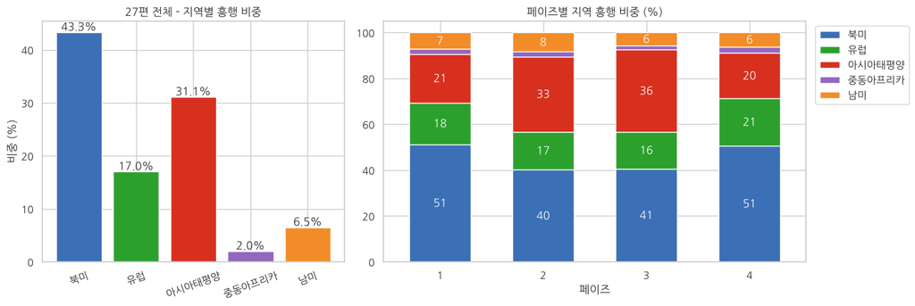

| phase | 북미 | 유럽 | 아시아태평양 | 중동아프리카 | 남미 |
| --- | --- | --- | --- | --- | --- |
| 1 | 51.3 | 18.1 | 21.3 | 2.2 | 7.2 |
| 2 | 40.2 | 16.6 | 32.7 | 2.2 | 8.3 |
| 3 | 40.6 | 16.1 | 35.8 | 1.8 | 5.8 |
| 4 | 50.7 | 20.6 | 19.8 | 2.8 | 6.1 |

```python
total = region_sum.sum()
share_total = (total / total.sum() * 100).round(1)

# 페이즈별 : 영화 금액을 모두 더한 뒤 비중 계산
phase_sum = region_sum.join(mov_info.set_index('movie_title')['phase']).groupby('phase').sum()
share_phase = (phase_sum.div(phase_sum.sum(axis=1), axis=0) * 100).round(1)

fig, axes = plt.subplots(1, 2, figsize=(14, 4.8), gridspec_kw={'width_ratios': [1, 1.4]})
colors = ['#3B6FB6', '#2CA02C', '#D7301F', '#9467BD', '#F28C28']

bars = axes[0].bar(share_total.index, share_total.values, color=colors)
axes[0].bar_label(bars, fmt='%.1f%%')
axes[0].set_title('27편 전체 - 지역별 흥행 비중')
axes[0].set_ylabel('비중 (%)')
axes[0].tick_params(axis='x', rotation=20)

share_phase.plot(kind='bar', stacked=True, color=colors, ax=axes[1], width=0.6)
for c in axes[1].containers:
    axes[1].bar_label(c, labels=[f'{v:.0f}' if v >= 5 else '' for v in c.datavalues], label_type='center', color='white')
axes[1].set_title('페이즈별 지역 흥행 비중 (%)')
axes[1].set_xlabel('페이즈'); axes[1].set_xticklabels(axes[1].get_xticklabels(), rotation=0)
axes[1].legend(bbox_to_anchor=(1.01, 1), loc='upper left')
plt.tight_layout()
plt.show()

share_phase
```

- 한줄 확인 : 27편 전체로는 **북미 43.3% > 아시아태평양 31.1% > 유럽 17.0% > 남미 6.5% > 중동아프리카 2.0%** 순이다.
  - 아시아태평양 비중은 페이즈 1 **21.3%** → 페이즈 2 **32.7%** → 페이즈 3 **35.8%**로 커졌다가, 페이즈 4에서 **19.8%**로 떨어졌다.
  - 반대로 북미는 51.3% → 40.2% → 40.6% → **50.7%**. 페이즈 4의 변화는 코로나19 시기 개봉 + **중국 미개봉**(4편 모두)의 영향이 크다.

### 3. 영화별 지역 비중 변화 (개봉 순서)

#### 3-1. 100% 누적 막대 (plotly) - 막대 위에 마우스를 올리면 금액과 비중이 보인다

```python
share = region_sum.div(region_sum.sum(axis=1), axis=0) * 100
share_long = (share.loc[order].reset_index()
              .melt(id_vars='movie_title', var_name='지역', value_name='비중(%)'))
share_long = share_long.merge(region_sum.stack().rename('흥행(백만$)').reset_index(), on=['movie_title', '지역'])
share_long = share_long.merge(mov_info[['movie_title', 'phase', '개봉연도']], on='movie_title')

fig = px.bar(share_long, x='movie_title', y='비중(%)', color='지역',
             color_discrete_sequence=colors, category_orders={'지역': regions, 'movie_title': order},
             hover_data={'흥행(백만$)': ':.1f', '비중(%)': ':.1f', 'phase': True, '개봉연도': True},
             title='MCU 영화별 지역 흥행 비중 (개봉 순서)')
fig.update_layout(xaxis_title='', yaxis_title='비중 (%)', height=550, xaxis_tickangle=-45,
                  legend_title_text='지역')
fig.show()
```

[interactive chart not shown]

- 한줄 확인 : 왼쪽(2008년)에서 오른쪽(2019년)으로 갈수록 **빨간색(아시아태평양) 구간이 넓어지고**, 2021년 4편에서 다시 좁아지는 모습이 한눈에 보인다.

```python
# 지역 비중이 가장 높은 / 낮은 영화
for r in ['북미', '아시아태평양', '유럽']:
    s = share[r]
    print(f'{r:6s} 최고 : {s.idxmax()} ({s.max():.1f}%)  /  최저 : {s.idxmin()} ({s.min():.1f}%)')
```

```
북미     최고 : Iron Man (57.7%)  /  최저 : Avengers: Endgame (34.5%)
아시아태평양 최고 : Avengers: Endgame (42.3%)  /  최저 : Captain America: The First Avenger (15.3%)
유럽     최고 : Thor (23.8%)  /  최저 : Ant-Man and the Wasp (13.5%)
```

- 한줄 확인 : 북미 비중 최고는 **Iron Man(57.7%)**, 최저는 **Avengers: Endgame(34.5%)**. 아시아태평양은 반대로 **Endgame 42.3%**가 최고, Captain America: The First Avenger 15.3%가 최저
  - 유럽은 최고 Thor(23.8%), 최저 Ant-Man and the Wasp(13.5%)로 다른 지역보다 영화 간 차이가 작다.
  - **Black Panther**는 페이즈 3 영화 중 유일하게 북미 비중이 50%를 넘는다(**55.2%**, 미국 내 흥행이 특히 컸던 영화).

#### 3-2. 개봉연도별 북미 vs 아시아태평양 비중 추이

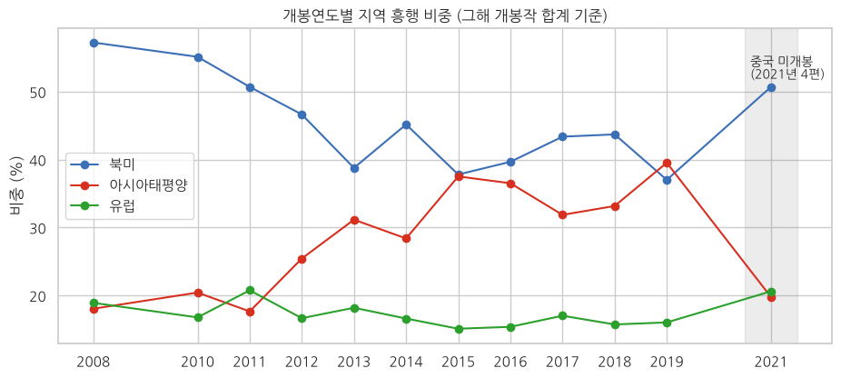

| 개봉연도 | 2008 | 2010 | 2011 | 2012 | 2013 | 2014 | 2015 | 2016 | 2017 | 2018 | 2019 | 2021 |
| --- | --- | --- | --- | --- | --- | --- | --- | --- | --- | --- | --- | --- |
| 북미 | 57.2 | 55.1 | 50.7 | 46.7 | 38.8 | 45.2 | 37.8 | 39.7 | 43.4 | 43.7 | 37.0 | 50.7 |
| 아시아태평양 | 18.1 | 20.4 | 17.7 | 25.4 | 31.2 | 28.4 | 37.5 | 36.5 | 31.9 | 33.2 | 39.5 | 19.8 |
| 유럽 | 18.9 | 16.8 | 20.8 | 16.7 | 18.2 | 16.6 | 15.1 | 15.4 | 17.0 | 15.7 | 16.0 | 20.6 |

```python
year_sum = region_sum.join(mov_info.set_index('movie_title')['개봉연도']).groupby('개봉연도').sum()
year_share = year_sum.div(year_sum.sum(axis=1), axis=0) * 100

fig, ax = plt.subplots(figsize=(11, 4.5))
for r, c in zip(['북미', '아시아태평양', '유럽'], ['#3B6FB6', '#D7301F', '#2CA02C']):
    ax.plot(year_share.index, year_share[r], marker='o', label=r, color=c)
ax.axvspan(2020.5, 2021.5, color='gray', alpha=0.15)
ax.text(2020.6, 52, '중국 미개봉\n(2021년 4편)', fontsize=10)
ax.set_xticks(year_share.index)
ax.set_ylabel('비중 (%)'); ax.set_title('개봉연도별 지역 흥행 비중 (그해 개봉작 합계 기준)')
ax.legend()
plt.show()

year_share[['북미', '아시아태평양', '유럽']].round(1).T
```

- 한줄 확인 : 2008년에는 북미 57.2%, 아시아태평양 18.1%였지만 **2015년에는 두 지역이 37.8% vs 37.5%로 거의 같아졌고**, 2019년에는 아시아태평양(39.5%)이 북미(37.0%)를 넘어섰다.
  - 2021년에는 북미 50.7%, 아시아태평양 19.8%로 2008~2012년 수준으로 돌아갔다.

### 4. 국가별 상위 시장

- 국가 순위에서는 앞에서 확인한 6개 '배분 컬럼'을 제외한다. `USA_and_Canada`는 미국+캐나다 합계이다.

```python
country = bo[~bo['국가'].isin(odd)]
print('국가(시장) 수 :', country['국가'].nunique())

top15 = (country.groupby(['국가', '지역'])['흥행'].sum().sort_values(ascending=False)
         .head(15).reset_index())
top15['전세계 비중(%)'] = (top15['흥행'] / bo['흥행'].sum() * 100).round(1)
top15['흥행'] = top15['흥행'].round(1)
top15
```

```
국가(시장) 수 : 67
```

|  | 국가 | 지역 | 흥행 | 전세계 비중(%) |
| --- | --- | --- | --- | --- |
| 0 | USA_and_Canada | 북미 | 9924.5 | 38.6 |
| 1 | China | 아시아태평양 | 3029.9 | 11.8 |
| 2 | United Kingdom | 유럽 | 1263.2 | 4.9 |
| 3 | South Korea | 아시아태평양 | 1058.6 | 4.1 |
| 4 | Mexico | 북미 | 809.9 | 3.2 |
| 5 | Brazil | 남미 | 802.0 | 3.1 |
| 6 | Australia | 아시아태평양 | 683.2 | 2.7 |
| 7 | France | 유럽 | 677.3 | 2.6 |
| 8 | Russia/CIS | 아시아태평양 | 601.3 | 2.3 |
| 9 | Germany | 유럽 | 553.7 | 2.2 |
| 10 | Japan | 아시아태평양 | 459.5 | 1.8 |
| 11 | Spain | 유럽 | 334.2 | 1.3 |
| 12 | Italy | 유럽 | 334.1 | 1.3 |
| 13 | India | 아시아태평양 | 304.0 | 1.2 |
| 14 | Taiwan | 아시아태평양 | 256.8 | 1.0 |

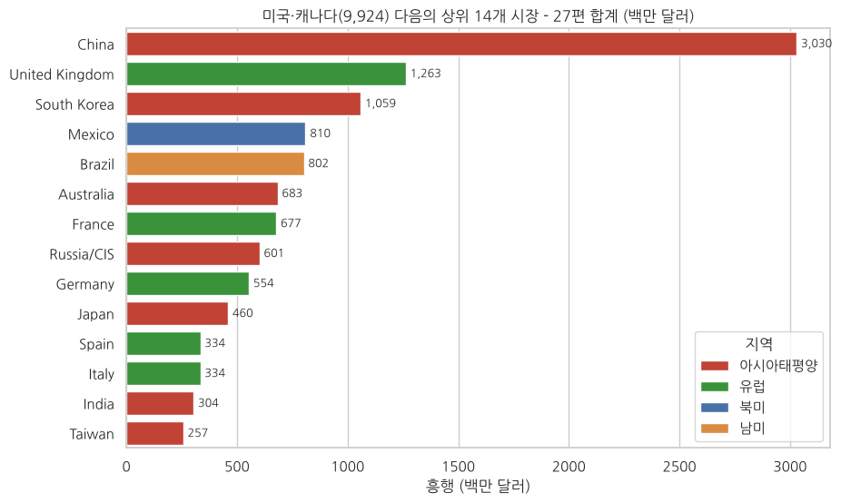

```python
fig, ax = plt.subplots(figsize=(10, 6))
sns.barplot(data=top15.iloc[1:], y='국가', x='흥행', hue='지역', dodge=False,
            palette=dict(zip(regions, colors)), ax=ax)
for i, v in enumerate(top15['흥행'].iloc[1:]):
    ax.text(v + 20, i, f'{v:,.0f}', va='center', fontsize=9)
ax.set_title(f"미국·캐나다({top15['흥행'].iloc[0]:,.0f}) 다음의 상위 14개 시장 - 27편 합계 (백만 달러)")
ax.set_xlabel('흥행 (백만 달러)'); ax.set_ylabel('')
plt.show()
```

- 한줄 확인 : 미국·캐나다(약 9,924, 전체의 **38.6%**) 다음으로 **중국 3,030(11.8%)**, 영국 1,263(4.9%), **한국 1,059(4.1%)**, 멕시코 810(3.2%), 브라질 802(3.1%) 순이다.
  - 중국은 6편이 빠져 있는데도 2위이고, 한국은 인구 대비 매우 큰 MCU 시장이다(영국에 이어 4위).

#### 4-1. 상위 10개 국가 × 영화 히트맵 (plotly) - 각 영화의 전세계 흥행 중 그 국가의 비중(%)

```python
top10 = top15['국가'].head(10).tolist()
ww = mov_info.set_index('movie_title')['전세계흥행']
heat = (country[country['국가'].isin(top10)]
        .pivot_table(index='국가', columns='movie_title', values='흥행')   # 결측(중국 6편)은 빈칸으로
        .reindex(index=top10, columns=order))
heat_pct = heat.div(ww[order], axis=1) * 100

fig = px.imshow(heat_pct.round(1), text_auto='.0f', aspect='auto', color_continuous_scale='Blues',
                labels={'x': '', 'y': '', 'color': '비중(%)'},
                title='영화별 전세계 흥행 중 국가 비중 (%) - 빈칸은 데이터 없음')
fig.update_layout(height=520, xaxis_tickangle=-45)
fig.show()
```

[interactive chart not shown]

```python
# 국가별 비중 요약 : 중국, 한국, 영국
summary = heat_pct.loc[['China', 'South Korea', 'United Kingdom']].T.describe().loc[['count', 'mean', 'min', 'max']].round(1)
print(summary)
print('중국 비중 최고 :', heat_pct.loc['China'].idxmax(), f"{heat_pct.loc['China'].max():.1f}%")
print('한국 비중 최고 :', heat_pct.loc['South Korea'].idxmax(), f"{heat_pct.loc['South Korea'].max():.1f}%")
```

```
국가     China  South Korea  United Kingdom
count   21.0         27.0            27.0
mean    12.6          4.2             5.0
min      1.3          1.0             3.7
max     22.5          6.9             6.8
중국 비중 최고 : Avengers: Endgame 22.5%
한국 비중 최고 : Black Widow 6.9%
```

- 한줄 확인 : **중국 비중**은 Iron Man 2(1.3%)처럼 초기에는 작았지만 점점 커져 **Avengers: Endgame에서 22.5%**로 최고였다(값이 있는 21편 평균 12.6%).
  - **한국**은 27편 모두 1.0~6.9%(평균 4.2%)로 꾸준하고, 최고는 Black Widow(6.9%) - 2021년 중국 미개봉 상황에서 상대적으로 비중이 커졌다.
  - 영국은 평균 5.0% 수준. 이처럼 **중국 한 나라의 유무**가 아시아태평양 비중 변화의 대부분을 설명한다.

```python
# 미국·캐나다를 뺀 각 영화의 1위 해외 시장
abroad = country[country['국가'] != 'USA_and_Canada'].dropna(subset=['흥행'])
top_abroad = abroad.loc[abroad.groupby('movie_title')['흥행'].idxmax(), ['movie_title', '국가', '흥행']]
top_abroad = top_abroad.set_index('movie_title').loc[order]
print(top_abroad['국가'].value_counts().to_string())
top_abroad.T
```

```
국가
China             18
United Kingdom     6
South Korea        2
Brazil             1
```

| movie_title | Iron Man | The Incredible Hulk | Iron Man 2 | Thor | Captain America: The First Avenger | The Avengers | Iron Man 3 | Thor: The Dark World | Captain America: The Winter Soldier | Guardians of the Galaxy | ... | Black Panther | Avengers: Infinity War | Ant-Man and the Wasp | Captain Marvel | Avengers: Endgame | Spider-Man: Far From Home | Black Widow | Shang-Chi and the Legend of the Ten Rings | Eternals | Spider-Man: No Way Home |
| --- | --- | --- | --- | --- | --- | --- | --- | --- | --- | --- | --- | --- | --- | --- | --- | --- | --- | --- | --- | --- | --- |
| 국가 | United Kingdom | United Kingdom | United Kingdom | United Kingdom | Brazil | China | China | China | China | China | ... | China | China | China | China | China | China | South Korea | United Kingdom | South Korea | United Kingdom |
| 흥행 | 34.28 | 15.16 | 30.46 | 22.52 | 20.68 | 86.3 | 121.2 | 55.34 | 115.62 | 86.35 | ... | 105.06 | 359.54 | 121.2 | 154.07 | 629.1 | 199.0 | 26.31 | 29.32 | 26.88 | 126.89 |

2 rows × 27 columns

- 한줄 확인 : 해외 1위 시장은 **중국 18편, 영국 6편, 한국 2편, 브라질 1편**이다.
  - 2012년 The Avengers부터 2019년 Far From Home까지 **18편 연속 중국이 해외 1위**, 2021년 중국 미개봉작 중 Black Widow·Eternals는 한국, Shang-Chi·No Way Home은 영국이 1위

### 5. 예산 대비 흥행 수익

- 흥행 배수 = 전세계 흥행 / 제작 예산 (마케팅비, 극장 배분 비율은 포함되지 않은 **단순 비율**)

```python
mov_info['흥행배수'] = (mov_info['전세계흥행'] / mov_info['예산']).round(2)
mov_info['페이즈'] = 'Phase ' + mov_info['phase'].astype(str)
r = mov_info['예산'].corr(mov_info['전세계흥행'])

fig = px.scatter(mov_info, x='예산', y='전세계흥행', color='페이즈', size='흥행배수', text='movie_title',
                 hover_data={'개봉연도': True, '흥행배수': True, 'movie_title': False},
                 category_orders={'페이즈': ['Phase 1', 'Phase 2', 'Phase 3', 'Phase 4']},
                 title=f'제작 예산 vs 전세계 흥행 (상관계수 r = {r:.2f}, 원 크기 = 흥행배수)')
fig.update_traces(textposition='top center', textfont_size=9)
fig.update_layout(height=600, xaxis_title='제작 예산 (백만 달러)', yaxis_title='전세계 흥행 (백만 달러)')
fig.show()
```

[interactive chart not shown]

```python
cols = ['movie_title', 'phase', '예산', '전세계흥행', '흥행배수']
rank = mov_info.sort_values('흥행배수', ascending=False)[cols]
print('흥행배수 상위 3편'); print(rank.head(3).to_string(index=False))
print('\n흥행배수 하위 3편'); print(rank.tail(3).to_string(index=False))
print('\n페이즈별 흥행배수'); print(mov_info.groupby('phase')['흥행배수'].agg(['count', 'mean', 'median']).round(2))
```

```
흥행배수 상위 3편
              movie_title  phase  예산   전세계흥행  흥행배수
  Spider-Man: No Way Home      4 200 1892.62  9.46
        Avengers: Endgame      3 356 2797.50  7.86
Spider-Man: Far From Home      3 160 1131.93  7.07

흥행배수 하위 3편
        movie_title  phase  예산  전세계흥행  흥행배수
           Eternals      4 200 402.06  2.01
        Black Widow      4 200 379.75  1.90
The Incredible Hulk      1 150 264.77  1.77

페이즈별 흥행배수
       count  mean  median
phase
1          6  3.60    3.06
2          6  4.70    4.38
3         11  5.61    5.03
4          4  4.06    2.44
```

- 한줄 확인 : 예산과 흥행의 상관계수는 **0.83**으로 높다(큰 예산 = 어벤져스 같은 대작).
  - 흥행배수 1위는 **Spider-Man: No Way Home(9.46배)**, 이어서 Avengers: Endgame(7.86배), Spider-Man: Far From Home(7.07배)
  - 하위는 **The Incredible Hulk(1.77배)**, Black Widow(1.90배), Eternals(2.01배)
  - 페이즈 3(11편)의 흥행배수 평균이 **5.61배**로 가장 높고, 페이즈 4는 평균 4.06배이지만 No Way Home을 빼면 나머지 3편은 1.90~2.88배(페이즈 4 중앙값 2.44배)에 그친다.

### 6. 정리

| 질문 | 기본 분석 | 추가 분석 결과 |
| --- | --- | --- |
| 회귀 모델은 믿을 만한가? | 테스트 R² -0.72 (3편) | 학습 R² 0.86 vs 테스트 -0.72 → **과적합**. LOOCV R² 0.30, 특이값(Captain Marvel 사용자 점수 3.0) 영향이 큼 |
| 어느 지역에서 가장 많이 벌었나? | 아시아 국가만 합계 비교 | 북미 **43.3%** > 아시아태평양 **31.1%** > 유럽 17.0% > 남미 6.5% > 중동아프리카 2.0% |
| 지역 비중은 어떻게 변했나? | - | 아시아태평양 페이즈1 21.3% → 페이즈3 **35.8%** → 페이즈4 19.8%. 2019년엔 아시아태평양(39.5%)이 북미(37.0%)를 추월 |
| 가장 큰 해외 시장은? | 중국 > 한국 > 호주 (아시아 내) | 전 세계 기준 **중국(11.8%)** > 영국(4.9%) > **한국(4.1%)** > 멕시코 > 브라질. 해외 1위 시장 중국 18편 |
| 중국 결측치의 의미는? | boxplot이 그려지지 않음 | 6편 결측 중 4편은 2021년 **중국 미개봉작** → 페이즈 4 아시아 비중 급감의 원인 |
| 예산 대비 수익은? | - | 예산-흥행 r = 0.83. 흥행배수 1위 No Way Home **9.46배**, 최하위 The Incredible Hulk 1.77배 |

#### 배운 점

- 데이터가 수십 행뿐이면 모델 점수 하나로 판단하지 말고 **학습/테스트 점수 비교, LOOCV**로 과적합을 확인하기
- 크기가 다른 대상(대작 vs 소품)을 비교할 때는 금액보다 **비중(%)** 이 공정하다.
- 합계 검증, 결측 위치, **값이 반복되는 컬럼** 같은 데이터 품질 확인이 해석을 바꾼다(중국 미개봉, 배분 컬럼).

#### 다음에 해 볼 분석

- 페이즈 4 이후(2022~) 영화와 중국 재개봉 여부를 추가해 아시아태평양 비중이 회복되는지 확인
- 국가별 인구·영화관 수 데이터를 붙여 **1인당 흥행**으로 시장 크기 비교